# Name: Tanner Woods

# Question 2

#### Question 2A

There are 665 women within the sample and 30 of them reported smoking during pregnancy.

#### Question 2B

*(See below for table)*

#### Question 2C

The mean for *fatheduc* is $\mu_{fatheduc} \approx 13.19$. From the dataset, only 1192 observations are used to compute the mean due to the presence of 196 NaN values for the variable.

# Question 3

#### Question 3A

*(See below for plots)*

Sturges' rule: Prone to underbinning on very small and very large datasets. Works best for datasets within the bounds of 30 < *n* < 200.

Freedman-Diaconis rule: Does not implicity assume a normal distribution as in Sturges' rule. Produces relatively thinner bin widths compared to bin widths computed from Sturge's rule; there is a risk of visually overstating importance of extreme tail-values, as can be seen in the plot.

#### Question 3B

*(See below for plots)*

#### Question 3C

*(See below for plot)*

*bwght* is approximately normally distributed, as it closely follows the parent normal distribution mapped onto the QQ plot. However, there is some room for improvement at its tails.

#### Question 3D

*(See below for plots)*

Notably, the median weight of infants born to mothers who smoked during pregnancy is lower than that of births non-smoking mothers. Additionally, the upper bound of birthweight given smoking mothers is drastically lower.

# Question 4

#### Question 4A

$\hat \beta_0 \approx 119.77$

$\hat \beta_1 \approx -0.51$

The model implies that cigarette use by pregnant mothers may entail an approximate 0.51oz. drop in birthweight per marginal cigarette smoked.

#### Question 4B

$\hat bwght_{cigs = 0} \approx 119.77$

$\hat bwght_{cigs = 3} \approx 118.23$

#### Question 4C

*(See below)*

#### Question 4D

*(See below for plot)*

# Question 2 (Code)

```python
import numpy as np
import matplotlib.pyplot as plt
import scipy.stats as stats
import pandas as pd
import wooldridge as woo
import math
import seaborn as sns
import statsmodels.api as sm
import statsmodels.formula.api as smf
```

## Question 2A (Code)

```python
bwght = woo.data('bwght')
bwght
```

|  | faminc | cigtax | cigprice | bwght | fatheduc | motheduc | parity | male | white | cigs | lbwght | bwghtlbs | packs | lfaminc |
| --- | --- | --- | --- | --- | --- | --- | --- | --- | --- | --- | --- | --- | --- | --- |
| 0 | 13.5 | 16.5 | 122.300003 | 109 | 12.0 | 12.0 | 1 | 1 | 1 | 0 | 4.691348 | 6.8125 | 0.0 | 2.602690 |
| 1 | 7.5 | 16.5 | 122.300003 | 133 | 6.0 | 12.0 | 2 | 1 | 0 | 0 | 4.890349 | 8.3125 | 0.0 | 2.014903 |
| 2 | 0.5 | 16.5 | 122.300003 | 129 | NaN | 12.0 | 2 | 0 | 0 | 0 | 4.859812 | 8.0625 | 0.0 | -0.693147 |
| 3 | 15.5 | 16.5 | 122.300003 | 126 | 12.0 | 12.0 | 2 | 1 | 0 | 0 | 4.836282 | 7.8750 | 0.0 | 2.740840 |
| 4 | 27.5 | 16.5 | 122.300003 | 134 | 14.0 | 12.0 | 2 | 1 | 1 | 0 | 4.897840 | 8.3750 | 0.0 | 3.314186 |
| ... | ... | ... | ... | ... | ... | ... | ... | ... | ... | ... | ... | ... | ... | ... |
| 1383 | 27.5 | 30.0 | 138.300003 | 110 | 12.0 | 12.0 | 4 | 1 | 1 | 0 | 4.700480 | 6.8750 | 0.0 | 3.314186 |
| 1384 | 5.5 | 30.0 | 138.300003 | 146 | NaN | 16.0 | 2 | 1 | 1 | 0 | 4.983607 | 9.1250 | 0.0 | 1.704748 |
| 1385 | 65.0 | 8.0 | 118.599998 | 135 | 18.0 | 16.0 | 2 | 0 | 1 | 0 | 4.905275 | 8.4375 | 0.0 | 4.174387 |
| 1386 | 27.5 | 8.0 | 118.599998 | 118 | NaN | 14.0 | 2 | 0 | 1 | 0 | 4.770685 | 7.3750 | 0.0 | 3.314186 |
| 1387 | 37.5 | 8.0 | 118.599998 | 111 | 16.0 | 13.0 | 2 | 0 | 1 | 0 | 4.709530 | 6.9375 | 0.0 | 3.624341 |

1388 rows × 14 columns

```python
print(f"{bwght['male'].value_counts()}")

bwght['pregcig'] = np.where((bwght['male'] == 0) & (bwght['cigs']) > 0, 1, 0)
print(f"\n{bwght['pregcig'].value_counts()}")

print(f"\n{np.mean(bwght[bwght['cigs'] != 0]['cigs'])}")
```

```
1    723
0    665
Name: male, dtype: int64

0    1358
1      30
Name: pregcig, dtype: int64

13.665094339622641
```

## Question 2B (Code)

```python
bwght.describe()
```

|  | faminc | cigtax | cigprice | bwght | fatheduc | motheduc | parity | male | white | cigs | lbwght | bwghtlbs | packs | lfaminc | pregcig |
| --- | --- | --- | --- | --- | --- | --- | --- | --- | --- | --- | --- | --- | --- | --- | --- |
| count | 1388.000000 | 1388.000000 | 1388.000000 | 1388.000000 | 1192.000000 | 1387.000000 | 1388.000000 | 1388.000000 | 1388.000000 | 1388.000000 | 1388.000000 | 1388.000000 | 1388.000000 | 1388.000000 | 1388.000000 |
| mean | 29.026657 | 19.552954 | 130.559006 | 118.699568 | 13.186242 | 12.935833 | 1.632565 | 0.520893 | 0.784582 | 2.087176 | 4.760031 | 7.418723 | 0.104359 | 3.071271 | 0.021614 |
| std | 18.739285 | 7.795598 | 10.244485 | 20.353964 | 2.745985 | 2.376728 | 0.894027 | 0.499743 | 0.411260 | 5.972688 | 0.190662 | 1.272123 | 0.298634 | 0.918065 | 0.145471 |
| min | 0.500000 | 2.000000 | 103.800003 | 23.000000 | 1.000000 | 2.000000 | 1.000000 | 0.000000 | 0.000000 | 0.000000 | 3.135494 | 1.437500 | 0.000000 | -0.693147 | 0.000000 |
| 25% | 14.500000 | 15.000000 | 122.800003 | 107.000000 | 12.000000 | 12.000000 | 1.000000 | 0.000000 | 1.000000 | 0.000000 | 4.672829 | 6.687500 | 0.000000 | 2.674149 | 0.000000 |
| 50% | 27.500000 | 20.000000 | 130.800003 | 120.000000 | 12.000000 | 12.000000 | 1.000000 | 1.000000 | 1.000000 | 0.000000 | 4.787492 | 7.500000 | 0.000000 | 3.314186 | 0.000000 |
| 75% | 37.500000 | 26.000000 | 137.000000 | 132.000000 | 16.000000 | 14.000000 | 2.000000 | 1.000000 | 1.000000 | 0.000000 | 4.882802 | 8.250000 | 0.000000 | 3.624341 | 0.000000 |
| max | 65.000000 | 38.000000 | 152.500000 | 271.000000 | 18.000000 | 18.000000 | 6.000000 | 1.000000 | 1.000000 | 50.000000 | 5.602119 | 16.937500 | 2.500000 | 4.174387 | 1.000000 |

## Question 2C (Code)

```python
bwght.isna().sum()
```

```
faminc        0
cigtax        0
cigprice      0
bwght         0
fatheduc    196
motheduc      1
parity        0
male          0
white         0
cigs          0
lbwght        0
bwghtlbs      0
packs         0
lfaminc       0
pregcig       0
dtype: int64
```

```python
np.nanmean(bwght['fatheduc'])

## np.mean also ignores the NaNs for some reason I'm too tired to figure out
## Return later to figure out
#np.mean(bwght['fatheduc']) - np.nanmean(bwght['fatheduc'])
```

```
13.186241610738255
```

# Question 3 (Code)

## Question 3A

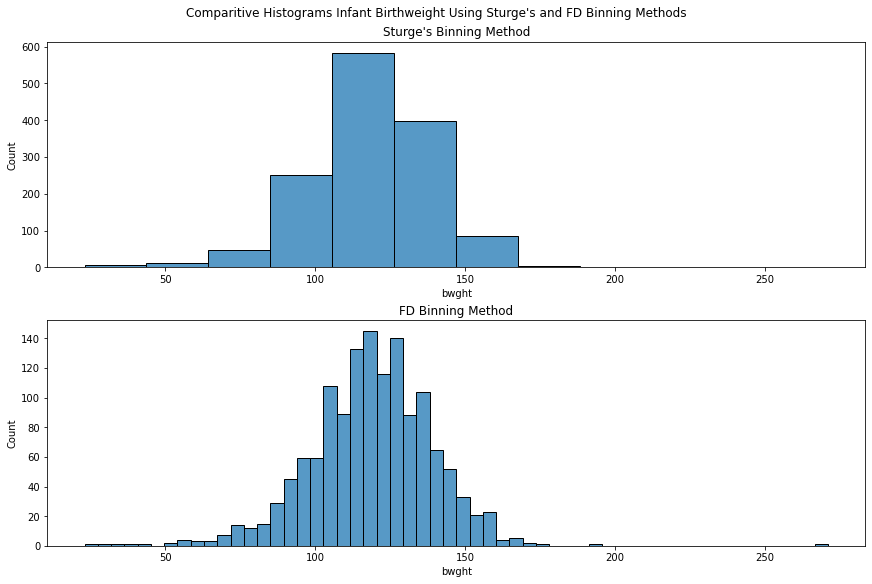

```python
fig, axes = plt.subplots(2, 1, figsize = (12,8), constrained_layout = True)
fig.suptitle("Comparitive Histograms Infant Birthweight Using Sturge's and FD Binning Methods")
sns.histplot(ax = axes[0], x = bwght['bwght'], bins = 'sturges')
sns.histplot(ax = axes[1], x = bwght['bwght'], bins = 'fd')
axes[0].set_title("Sturge's Binning Method")
axes[1].set_title("FD Binning Method")
plt.show()
```

## Question 3B

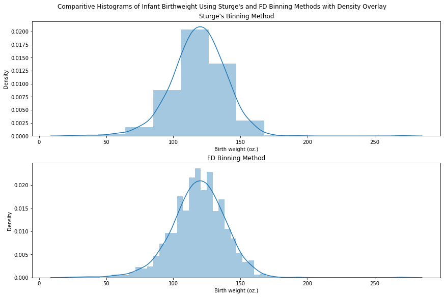

```python
fig, axes = plt.subplots(2, 1, figsize = (12,8), constrained_layout = True)
fig.suptitle("Comparitive Histograms of Infant Birthweight Using Sturge's and FD Binning Methods with Density Overlay")
sns.distplot(ax = axes[0], x = bwght['bwght'], bins = 'sturges')
sns.distplot(ax = axes[1], x = bwght['bwght'], bins = 'fd')
axes[0].set_title("Sturge's Binning Method")
axes[1].set_title("FD Binning Method")
axes[0].set_xlabel("Birth weight (oz.)")
axes[1].set_xlabel("Birth weight (oz.)")
plt.show()
```

## Question 3C

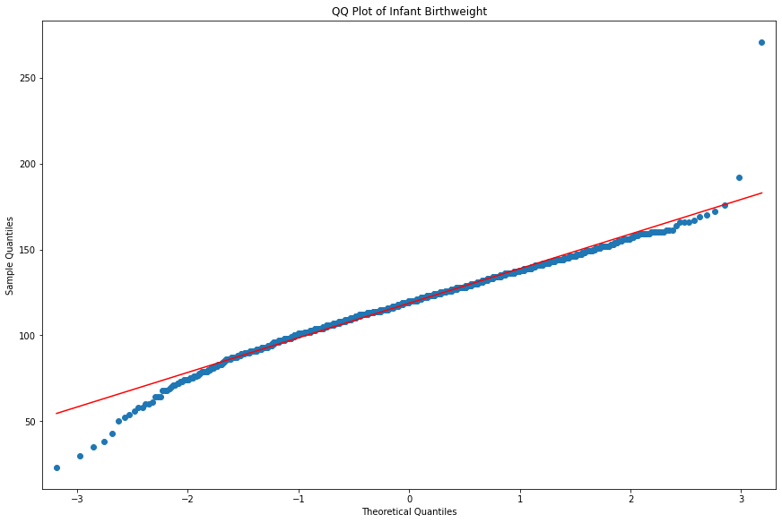

```python
fig, axes = plt.subplots(figsize = (12,8), constrained_layout = True)
sm.qqplot(bwght['bwght'], line = 'r', ax = axes);
plt.title("QQ Plot of Infant Birthweight")
plt.show()
```

## Question 3D

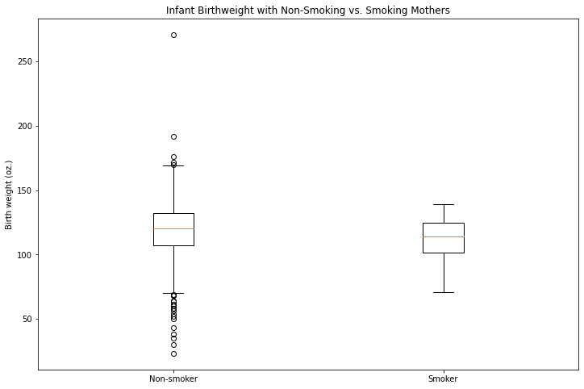

```python
plt.figure(figsize = (12,8))
cond_frame = bwght[['bwght','pregcig']]
cond_series = [cond_frame[cond_frame['pregcig'] == 0].bwght,
              cond_frame[cond_frame['pregcig'] == 1].bwght]
plt.boxplot(cond_series)
plt.ylabel("Birth weight (oz.)")
plt.xticks([1,2], ["Non-smoker", "Smoker"])
plt.title("Infant Birthweight with Non-Smoking vs. Smoking Mothers")
plt.show()
```

# Question 4

## Question 4A

```python
Regression = smf.ols('bwght ~ cigs', data = bwght)
Model = Regression.fit()
Model.params
```

```
Intercept    119.771900
cigs          -0.513772
dtype: float64
```

## Question 4C

```python
Model.resid.mean()
```

```
3.771814752939783e-14
```

## Question 4D

[figure not shown]

```python
plt.figure(figsize = (12,8))
sns.regplot(x = Model.fittedvalues, y = bwght['bwght'], lowess = True, line_kws = {'color': 'red'})
plt.title("Predicted vs. Observed Infant Birthweight")
plt.xlabel("Observed birth weight (oz.)")
plt.ylabel("Predicted birth weight (oz.)")
plt.grid()
plt.show()
```